# IPython Notebook: más que una consola en el navegador

### TIC_ec 2014 <- Universidad de Cuenca

[figure not shown]

**Requerimientos para el tutorial**:

- Librerias Sistema:
- pandoc
- linuxdoc-tools-latex
- texlive-full (para generacion correcta de pdfs)
- Librerias Python:
- ipython 2.0+
- pandas
- openpyxl
- matplotlib
- rpy2

## Introducción a IPython

- Más que intérprete de comandos mejorado para python
- Sistema de ayuda incluido
- Exploración de objetos (?)
- Autocompletado de código con la tecla Tab
- Funciones mágicas (%)
- Historial de comandos y salidas
- Llamadas a comandos del sistema (!)
- Se puede ejecutar código de otros lenguajes: *R, Octave, Cython, Bash, Perl, Ruby, etc.*

## Que es el Notebook de IPython

- **"El paper ejecutable para los científicos"**
- Un intérprete interactivo avanzado que ha revolucionando la manera en que se utiliza Python en ámbitos *científicos, conferencias y tutoriales*
- Mucho ahorro de tiempo en escritura de código y pruebas
- Permite escribir en formato *Markdown, HTML, o texto puro (raw)*
- Permite escribir en **LateX**
- Permite incluir imágenes, links a archivos locales, videos, etc
- Exporta hacia diferentes formatos tales como: PDF, RST, Latex, reveal.js, etc
- Trabaja iniciando **servidor web** local y luego sirviendo páginas desde tal servidor: **Conozcámoslo entonces !!!** ....

## Trabajar con el teclado en IPython Notebook

(Conjunto compatible de atajos de teclado) - Shift-Enter : run cell - Ctrl-Enter : run cell in-place - Alt-Enter : run cell, insert below - Ctrl-m x : cut cell - Ctrl-m c : copy cell - Ctrl-m v : paste cell - Ctrl-m d : delete cell - Ctrl-m z : undo last cell deletion - Ctrl-m - : split cell - Ctrl-m a : insert cell above - Ctrl-m b : insert cell below - Ctrl-m o : toggle - Ctrl-m O : toggle output scroll - Ctrl-m l : toggle line numbers - Ctrl-m s : save notebook - Ctrl-m j : move cell down - Ctrl-m k : move cell up - Ctrl-m y : code cell - Ctrl-m m : markdown cell - Ctrl-m t : raw cell - Ctrl-m 1-6 : heading 1-6 cell - Ctrl-m p : select previous - Ctrl-m n : select next - Ctrl-m i : interrupt kernel - Ctrl-m . : restart kernel - Ctrl-m h : show keyboard shortcuts

## Formateando el texto en IPyNB

Texto puro

# Titulo 1

## Titulo 2

### Titulo 3

Lista: - uno - dos - tres

#### Tablas en Markdown

| Característica | Valor |
| --- | --- |
| Sistema Operativo | Linux Mint |
| Ram | 4MG |
| Disco | 100GB |
| Lenguaje de Programación | Python |

#### Formateando código fuente en markdown

Javascript

```javascript
    console.log('Hello world')
```

Java

```java
    public static void main(String [] args){
        System.out.println("hola mundo");
    }
```

Python

```python
    def hello_ipython_notebook():
        print "Hello IPython Notebook"
```

R

```r
    df <- data.frame(x=c('a','e','i','o','u'), y=1:5)
```

## HTML

**negrita**  
*cursiva*  
subrayado

# LATEX

$polinomio -> x^4 - 11x^3 + 9x^2 + 11x - 10$

$\pi r^2$

$D_{KL}(P||Q)=\sum\limits_{i}ln(\frac{P(i))}{Q(i)})P(i)$

## Comandos mágicos de IPython Notebook

```python
%lsmagic
```

```
Available line magics:
%alias  %alias_magic  %autocall  %automagic  %autosave  %bookmark  %cat  %cd  %clear  %colors  %config  %connect_info  %cp  %debug  %dhist  %dirs  %doctest_mode  %ed  %edit  %env  %gui  %hist  %history  %install_default_config  %install_ext  %install_profiles  %killbgscripts  %ldir  %less  %lf  %lk …

Available cell magics:
%%!  %%HTML  %%SVG  %%bash  %%capture  %%debug  %%file  %%html  %%javascript  %%latex  %%perl  %%prun  %%pypy  %%python  %%python2  %%python3  %%ruby  %%script  %%sh  %%svg  %%sx  %%system  %%time  %%timeit  %%writefile

Automagic is ON, % prefix IS NOT needed for line magics.
```

```python
%%file /tmp/boo.txt
esto es una prueba
desde un ipynoote
```

```
Writing /tmp/boo.txt
```

```python
%who_ls
```

```
['math']
```

```python
%matplotlib inline
```

```python
%config InlineBackend.figure_format = 'png'
```

## Interacción con el Sistema Operativo

```python
%ls data
```

```
housing.csv  sgaunl.csv  sgaunl.xlsx
```

```python
%pwd
```

```
u'/home/miltonlab/Documentos/pyresearch/ticec2014'
```

## Contenido hypermedia en IPython Notebook

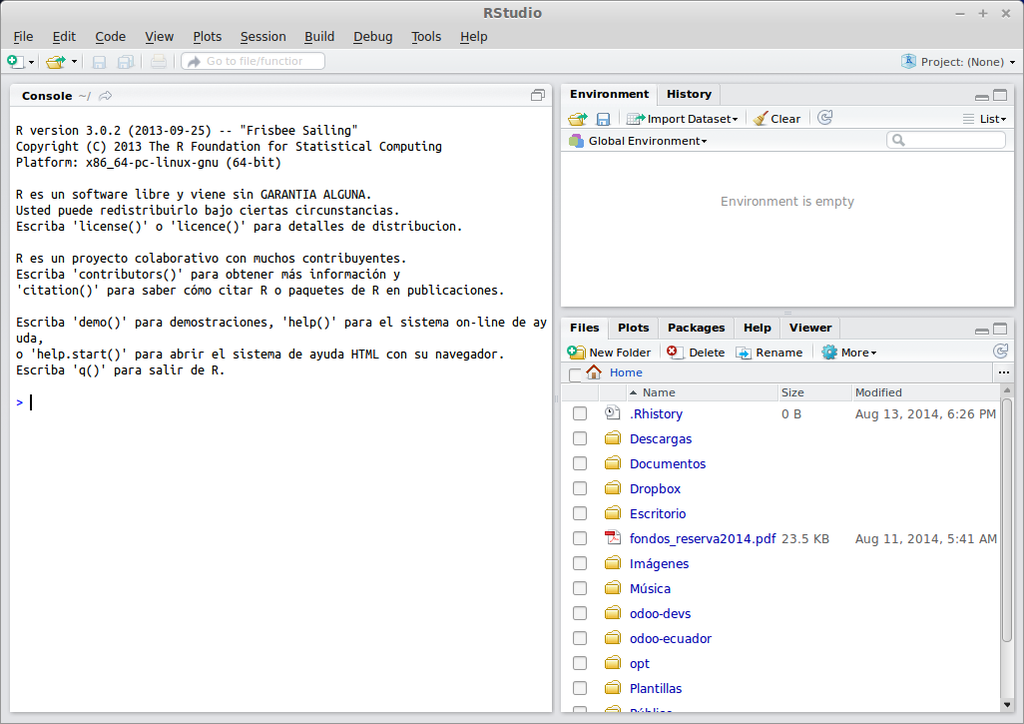

```python
#Mostrar imágenes
from IPython.display import Image
from IPython.display import display
display(Image('images/rstudio.png', width=700, height=450))
```

```python
#Videos embebidos de Youtube
from IPython.display import YouTubeVideo
YouTubeVideo('nRHBdkxVn48')
```

[video not shown]

```python
#Incrustar páginas HTML
#from IPython.display import HTML
#HTML('<iframe src="http://pycon.com.ar/pyconar2014/" width=500 height=600>')
```

## Introducción al trabajo científico con Python

```python
import numpy
import matplotlib
```

```python
a = numpy.array([[5,2,9,4],[1,8,8,9],[6,6,4,7],[3,5,6,2]])
a
# Seleccionar columna 2
a[:,2]
# Seleccionar fila 2
a[2,:]
# Selcción de un subarreglo
a[0:2,1:3]
# Selección condicional
numpy.where(a%2==0,a,0)
a>5
a*3
# Determinante de un arreglo
numpy.linalg.det(a)
b = numpy.array([[5, 4, 2, 0], [9, 9, 6, 1], [3, 0, 5, 3], [8, 0, 6, 1]])
b
c = a * b
c
```

```
array([[25,  8, 18,  0],
       [ 9, 72, 48,  9],
       [18,  0, 20, 21],
       [24,  0, 36,  2]])
```

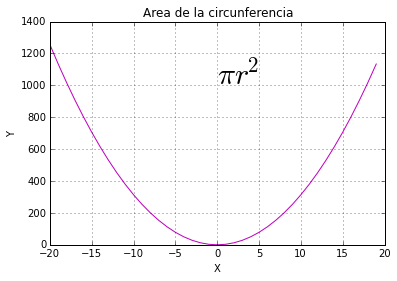

```python
x=numpy.arange(-20,20)
matplotlib.pyplot.title('Area de la circunferencia')
matplotlib.pyplot.xlabel('X')
matplotlib.pyplot.ylabel('Y')
matplotlib.pyplot.grid(True)
# Latex
matplotlib.pyplot.text(0,1000, r'$\pi r^2$', fontsize=30)
matplotlib.pyplot.plot(x, x*x*numpy.pi, 'm')
#pyplot.show()
```

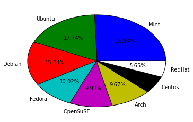

```python
# Graficos de Pastel
distros = ['Mint', 'Ubuntu', 'Debian', 'Fedora', 'OpenSuSE', 'Arch',
           'Centos', 'RedHat']
# Datos según http://distrowatch.com la tercera semana de Mayo del 2014
ranking = [3105, 2157, 1865, 1218, 1207, 1176, 743, 687]

matplotlib.pyplot.pie(ranking, labels=distros, autopct='%.2f%%')
```

## Análisis de Datos con Python desde IPyNotebook

```python
import pandas
# Datos de ingresos de extranjeros al ecuador primer cuatrimestre segpún:
# http://servicios.turismo.gob.ec/images/estadisticas/Boletin-abril-2014-comprimido.pdf
turismo = pandas.DataFrame({'Anio': [2010, 2011, 2012, 2013, 2014],
                        'enero' : [96109, 105548, 127116, 130842, 152576],
                        'febrero' : [89924, 86421, 99521, 103768, 124584],
                        'marzo' : [82452, 87495, 96948, 113361, 114007],
                        'abril' : [70540, 87507, 92627, 89669, 118614]
                        })
```

```python
turismo
```

|  | Anio | abril | enero | febrero | marzo |
| --- | --- | --- | --- | --- | --- |
| 0 | 2010 | 70540 | 96109 | 89924 | 82452 |
| 1 | 2011 | 87507 | 105548 | 86421 | 87495 |
| 2 | 2012 | 92627 | 127116 | 99521 | 96948 |
| 3 | 2013 | 89669 | 130842 | 103768 | 113361 |
| 4 | 2014 | 118614 | 152576 | 124584 | 114007 |

```python
turismo.columns
```

```
Index([u'Anio', u'abril', u'enero', u'febrero', u'marzo'], dtype='object')
```

```python
turismo.describe()
```

|  | Anio | abril | enero | febrero | marzo |
| --- | --- | --- | --- | --- | --- |
| count | 5.000000 | 5.000000 | 5.000000 | 5.000000 | 5.000000 |
| mean | 2012.000000 | 91791.400000 | 122438.200000 | 100843.600000 | 98852.600000 |
| std | 1.581139 | 17281.729986 | 22244.652643 | 15009.638846 | 14506.479321 |
| min | 2010.000000 | 70540.000000 | 96109.000000 | 86421.000000 | 82452.000000 |
| 25% | 2011.000000 | 87507.000000 | 105548.000000 | 89924.000000 | 87495.000000 |
| 50% | 2012.000000 | 89669.000000 | 127116.000000 | 99521.000000 | 96948.000000 |
| 75% | 2013.000000 | 92627.000000 | 130842.000000 | 103768.000000 | 113361.000000 |
| max | 2014.000000 | 118614.000000 | 152576.000000 | 124584.000000 | 114007.000000 |

```python
turismo['enero']
```

```
0     96109
1    105548
2    127116
3    130842
4    152576
Name: enero, dtype: int64
```

```python
turismo[['enero', 'febrero']]
```

|  | enero | febrero |
| --- | --- | --- |
| 0 | 96109 | 89924 |
| 1 | 105548 | 86421 |
| 2 | 127116 | 99521 |
| 3 | 130842 | 103768 |
| 4 | 152576 | 124584 |

```python
# Aquellos años que en enero tienen valores sobre la media
turismo[turismo.enero > turismo.enero.mean()] [['Anio','enero']]
```

|  | Anio | enero |
| --- | --- | --- |
| 2 | 2012 | 127116 |
| 3 | 2013 | 130842 |
| 4 | 2014 | 152576 |

```python
unl = pandas.read_csv('./data/sgaunl.csv')
```

```python
unl
```

|  | Unnamed: 0 | id | nombre | matriculados | aprobados | reprobados |
| --- | --- | --- | --- | --- | --- | --- |
| 0 | 8 | 25 | Pregrado Septiembre 2008 - Febrero 2009 | 12616 | 10917 | 1680 |
| 1 | 9 | 26 | Pregrado Marzo 2009 - Julio 2009 | 11723 | 10012 | 1668 |
| 2 | 10 | 28 | Pregrado Septiembre 2009 - Febrero 2010 | 21545 | 18563 | 2863 |
| 3 | 4 | 30 | Admisiones Pregrado | 0 | 0 | 0 |
| 4 | 13 | 34 | Pregrado Marzo 2010 - Julio 2010 | 21810 | 19413 | 2152 |
| 5 | 11 | 35 | Admisiones Pregrado 2010 | 1 | 1 | 0 |
| 6 | 12 | 36 | Pregrado Septiembre 2010 Febrero 2011 | 21439 | 18868 | 2258 |
| 7 | 18 | 42 | Pregrado Marzo 2011 - Julio 2011 | 18071 | 16515 | 1492 |
| 8 | 16 | 43 | Admisiones Pregrado 2011 | 0 | 0 | 0 |
| 9 | 35 | 45 | Pregrado Septiembre 2011 Febrero 2012 | 18011 | 16121 | 1721 |
| 10 | 34 | 65 | Pregrado Marzo 2012 Julio 2012 | 16049 | 14907 | 923 |
| 11 | 40 | 68 | Pregrado Septiembre 2012 Febrero 2013 | 12837 | 11647 | 984 |
| 12 | 45 | 74 | Pregrado Marzo 2013 Julio 2013 | 11980 | 11182 | 722 |
| 13 | 43 | 77 | Pregrado Septiembre 2013 Febrero 2014 | 9227 | 8478 | 749 |
| 14 | 50 | 81 | Pregrado Marzo-Julio 2014 | 8347 | 8 | 0 |

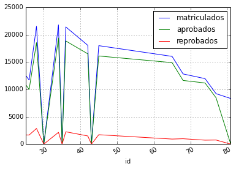

```python
seccion = unl[['matriculados', 'aprobados', 'reprobados']]
seccion.plot(x=unl.id, rot=30)
```

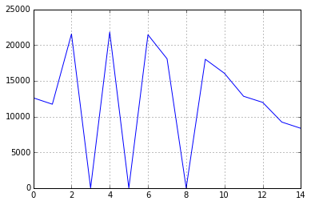

```python
unl.matriculados.plot(x_compat=True)
```

```python
unl.to_excel('./data/sgaunl.xlsx')
```

```python
# Consumo de datos en formato json desde el portal http://datosabiertos.ec/
from urllib2 import urlopen
urlagua = urlopen('http://www.datosabiertos.ec/storage/f/2013-10-25T06%3A52%3A19.508Z/ecuador-agua-consumos.json')
dataagua = pandas.read_json((urlagua))
dataagua.head(4)
```

|  | created_at | id | maximoAmazonia | maximoConsumo | maximoCosta | maximoSierra | mediaAmazonia | mediaConsumo | mediaCosta | mediaSierra | ... | valorMediaAmazonia | valorMediaCosta | valorMediaSierra | valorMinimo | valorMinimoAmazonia | valorMinimoCosta | valorMinimoSierra | valorTotalAmazonia | valorTotalCosta | valorTotalSierra |
| --- | --- | --- | --- | --- | --- | --- | --- | --- | --- | --- | --- | --- | --- | --- | --- | --- | --- | --- | --- | --- | --- |
| 0 | 2013-10-25 06:45:20 | 1 | 999 | 999 | 999 | 999 | 100.42 | 34.15 | 32.61 | 35.65 | ... | 10.71 | 11.25 | 11.38 | 0.89 | 1 | 0.99 | 0.89 | 879.733 | 11.907 | 17.438 |

1 rows × 34 columns

```python
len (dataagua.columns)
```

```
34
```

## Programando en "R" desde IPython Notebook

```python
%load_ext rmagic
```

```python
%%R
setwd('.')
fileUrl <- 'https://d396qusza40orc.cloudfront.net/getdata%2Fdata%2Fss06hid.csv'
download.file(fileUrl, destfile='./data/housing.csv', method='curl')
```

```python
%R list.files('./data')
```

```
array(['housing.csv'],
      dtype='|S11')
```

```python
%%R
house <- read.csv('./data/housing.csv')
## For the state of Idaho how many properties are worth $1,000,000 or more?
expensives <- subset(house, ST==16 & VAL==24)
print (nrow((expensives)))
print (ncol(expensives))
```

```
[1] 53
[1] 188
```

## Widgets interactivos (sobresaliente en IPython 2.0+)

```python
from IPython.html import widgets
from IPython.display import display
sld = widgets.FloatSliderWidget(
    value=30, min=2, max=32, step=1, description='Test Float Widget'
)
chkb = widgets.CheckboxWidget(
    value=True, description='Test Checkbox'
)
drpd = widgets.DropdownWidget(
    values=[1,2,3,4,5,6], value=2, description='Test DropDown'
)

display(sld)
display(chkb)
display(drpd)
```

```python
def conectar(val):
    print val
    return val
w = widgets.interactive(conectar, val=widgets.FloatSliderWidget(
    value=128.0, min=0, max=255.0, step=1.0))
display(w)
```

```
128.0
```

# Links interesantes

- http://pyvideo.org/video/2798/ipython-revealjs-attacks-again-but-now-it-is [IPyNb with Reveal.js alive ]
- http://nbviewer.ipython.org/gist/ellisonbg/3837783/TwitterNetworkX.ipynb [Analisis of twitter stream data]
- http://nbviewer.ipython.org/github/NelisW/ComputationalRadiometry/blob/master/01-IPythonHintsAndTips.ipynb